# Assignment II_Group4

```python
import numpy as np
import pandas as pd
import matplotlib.pyplot as plt
import seaborn as sns

from sklearn import metrics
from statsmodels.tsa.seasonal import seasonal_decompose
from sklearn.linear_model import LinearRegression
from statsmodels.tsa.api import ExponentialSmoothing, SimpleExpSmoothing, Holt
```

### Q1. Read the data as an appropriate Time Series data and plot the data.

```python
# Importing sparkling dataset into a dataframe - sparkling and set the Index to column Year-Month.

sparkling = pd.read_csv('Sparkling_Dataset.csv')
sparkling['YearMonth'] = pd.date_range(start = '1980-01-01', periods=len(sparkling), freq='M')
sparkling.set_index('YearMonth', inplace=True)
```

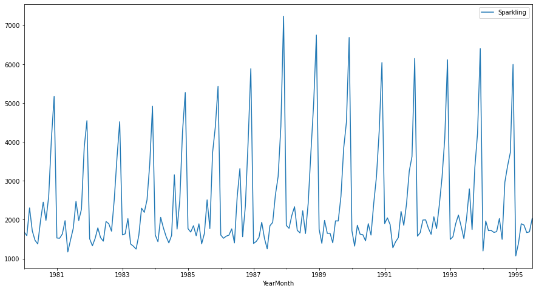

```python
# Plot the sparkling data into time series plot.

from pylab import rcParams
rcParams['figure.figsize'] = 15, 8
sparkling.plot()
plt.show()
```

### Q2. Perform appropriate Exploratory Data Analysis to understand the data and also perform decomposition.

```python
# Perform different exploratory data analysis to understand the data - check for total rows, columns data.

sparkling.shape
```

```
(187, 1)
```

```python
# Perform different exploratory data analysis to understand the data - check for total size of data.

sparkling.size
```

```
187
```

```python
# Perform different exploratory data analysis to understand the data - check for differnt attributes.

sparkling.info()
```

```
<class 'pandas.core.frame.DataFrame'>
DatetimeIndex: 187 entries, 1980-01-31 to 1995-07-31
Data columns (total 1 columns):
 #   Column     Non-Null Count  Dtype
---  ------     --------------  -----
 0   Sparkling  187 non-null    int64
dtypes: int64(1)
memory usage: 2.9 KB
```

```python
# Perform different exploratory data analysis to understand the data - check for count, mean, median.

sparkling.describe()
```

|  | Sparkling |
| --- | --- |
| count | 187.000000 |
| mean | 2402.417112 |
| std | 1295.111540 |
| min | 1070.000000 |
| 25% | 1605.000000 |
| 50% | 1874.000000 |
| 75% | 2549.000000 |
| max | 7242.000000 |

```python
# Perform different exploratory data analysis to understand the data - check for data types.

sparkling.dtypes
```

```
Sparkling    int64
dtype: object
```

```python
# Perform different exploratory data analysis to understand the data - check top 5 records.

sparkling.head()
```

| YearMonth | Sparkling |
| --- | --- |
| 1980-01-31 | 1686 |
| 1980-02-29 | 1591 |
| 1980-03-31 | 2304 |
| 1980-04-30 | 1712 |
| 1980-05-31 | 1471 |

```python
# Perform different exploratory data analysis to understand the data - check last 5 records.

sparkling.tail()
```

| YearMonth | Sparkling |
| --- | --- |
| 1995-03-31 | 1897 |
| 1995-04-30 | 1862 |
| 1995-05-31 | 1670 |
| 1995-06-30 | 1688 |
| 1995-07-31 | 2031 |

```python
# Perform different exploratory data analysis to understand the data - check for null values.

print(sparkling.isnull().sum())
```

```
Sparkling    0
dtype: int64
```

```python
# Perform different exploratory data analysis to understand the data - check for duplicates.

duplicate_rows = sparkling[sparkling.duplicated()]
print('Number of Duplicate Rows - ', duplicate_rows.shape)
```

```
Number of Duplicate Rows -  (11, 1)
```

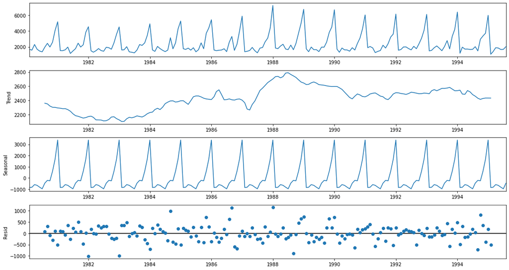

```python
# Peform decomposition 'additive' - to get insight into seasonality, trend, randomness.

decomposition = seasonal_decompose(sparkling, model='additive', period=12)
decomposition.plot()
plt.show()
```

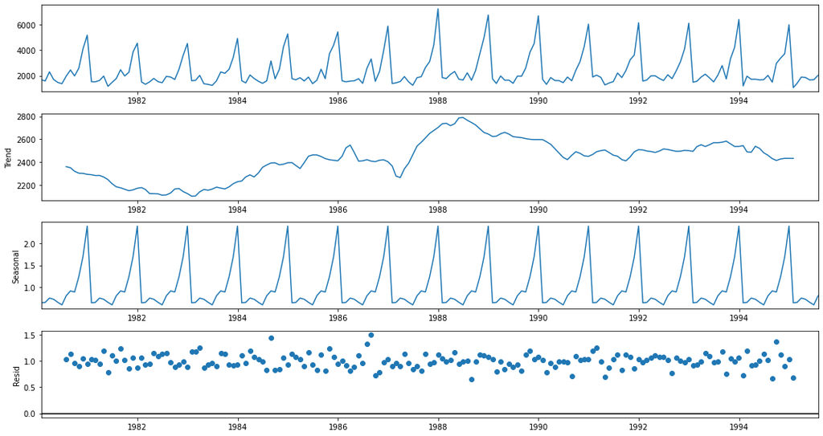

```python
# Peform decomposition 'multiplicative' - to get insight into seasonality, trend, randomness.

decomposition = seasonal_decompose(sparkling, model='multiplicative', period=12)
decomposition.plot()
plt.show()
```

### Q3. Split the data into training and test. The test data should start in 1991.

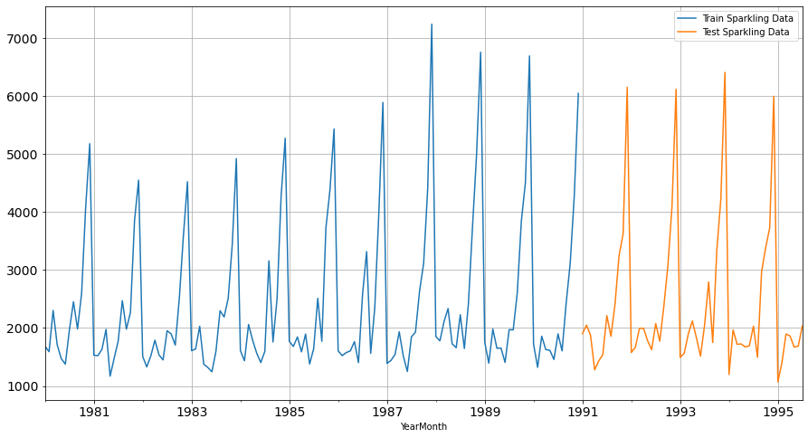

```python
# Divid the data into train & test (for records > 1991).

sparkling_train = sparkling[sparkling.index < '1991']
sparkling_test  = sparkling[sparkling.index >= '1991']

# Plot the tratin & test data into a chart.

sparkling_train['Sparkling'].plot(fontsize=14)
sparkling_test['Sparkling'].plot(fontsize=14)
plt.grid()
plt.legend(['Train Sparkling Data', 'Test Sparkling Data'])
plt.show()
```

### Q4. Build various exponential smoothing models on the training data and evaluate the model using RMSE on the test data. Other models such as regression,naïve forecast models and simple average models. should also be built on the training data and check the performance on the test data using RMSE.

### 1. Naive Model

$\hat{y}_{t+1} = y_t$

#### In Naive Model, the prediction for tomorrow is the same as today and the prediction for day after tomorrow is tomorrow and since the prediction of tomorrow is same as today,therefore the prediction for day after tomorrow is same as today.

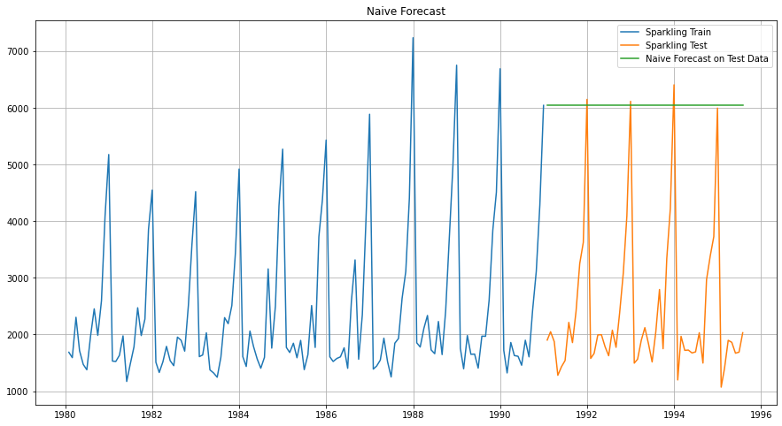

```python
# Training the model on sparkling_train dataset to predict the last value as the future value.

NaiveModel_Train = sparkling_train.copy()
NaiveModel_Test = sparkling_test.copy()

NaiveModel_Test['Naive'] = np.asarray(sparkling_train['Sparkling'])[len(np.asarray(sparkling_train['Sparkling']))-1]

# Plot the train and test data into forecast.

plt.plot(NaiveModel_Train['Sparkling'], label='Sparkling Train')
plt.plot(sparkling_test['Sparkling'], label='Sparkling Test')

plt.plot(NaiveModel_Test['Naive'], label='Naive Forecast on Test Data')

plt.legend(loc='best')
plt.title("Naive Forecast")
plt.grid();
```

```python
# Calculating the error for the Vaive Forecast.

Naive_Model_Error = metrics.mean_squared_error(sparkling_test['Sparkling'],NaiveModel_Test['Naive'],squared=False)
print("For Naive Bayees forecast on the Test Data, RMSE is : %3.3f" %(Naive_Model_Error))
```

```
For Naive Bayees forecast on the Test Data, RMSE is : 3864.279
```

### Inference (Naive Model)

Naive Model assumes the last value of the training dataset to be applicable, for all the test dataset and hence is not a suitable method in time series forecasting which has Trend & Seasonality. The RMSE is also very high here (3865).

### 2. Linear Regression Model

#### Linear Regression typically is not suitable for time series analysis. This model that assumes a linear relationship between the input variables (x) and the single output variable (y). More specifically, that y can be calculated from a linear combination of the input variables.

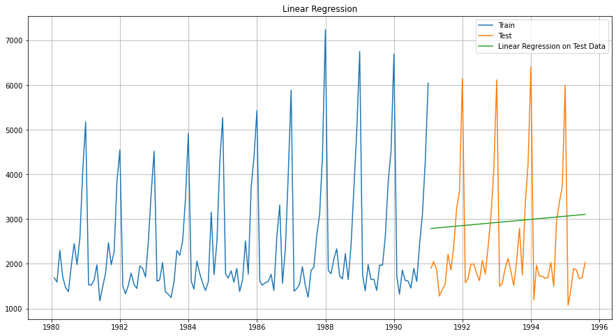

```python
# Training the model on sparkling_train dataset to predict the last value as the future value with linear regression.

train_time = [i+1 for i in range(len(sparkling_train))]
test_time = [i+133 for i in range(len(sparkling_test))]

LinearRegression_Train = sparkling_train.copy()
LinearRegression_Test = sparkling_test.copy()

LinearRegression_Train['Time'] = train_time
LinearRegression_Test['Time'] = test_time

lr = LinearRegression()
lr.fit(LinearRegression_Train[['Time']], LinearRegression_Train[['Sparkling']])

LinearRegression_Train['SaleOnTime'] = lr.predict(LinearRegression_Train[['Time']])
LinearRegression_Test['SaleOnTime'] = lr.predict(LinearRegression_Test[['Time']])

# Plot the train and test data into forecast.

plt.plot(sparkling_train['Sparkling'], label='Train')
plt.plot(sparkling_test['Sparkling'], label='Test')
plt.plot(LinearRegression_Test['SaleOnTime'], label='Linear Regression on Test Data')

plt.legend(loc='best')
plt.title("Linear Regression")

plt.grid();
```

```python
# Calculate the error (RMSE Value) for Linear Regression Model.

Linear_Regression_Error = metrics.mean_squared_error(sparkling_test['Sparkling'],LinearRegression_Test['SaleOnTime'],squared=False)
print("For Linear Regression forecast on the Test Data, RMSE is : %3.3f" %(Linear_Regression_Error))
```

```
For Linear Regression forecast on the Test Data, RMSE is : 1389.135
```

### Inference (Linear Regression)

Linear Regression is not an effective way of doing time series forecasting as it does forecasting on two parameters (Time whcih is an index indicating record number and the sale of wine). The RMSE is also very high and close to 1390.

### 3. Simple Average Model

#### In Simple Average Method, forecast is done by taking average of the traning data set and using fixed value to predict the test.

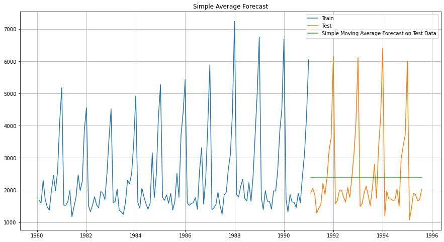

```python
# Training the model on sparkling_train dataset to predict the last value as the future value with simple moving average.

SimpleAverage_Train = sparkling_train.copy()
SimpleAverage_Test = sparkling_test.copy()
SimpleAverage_Test['AverageForecast'] = SimpleAverage_Train['Sparkling'].mean()

# Plot the train and test data into forecast.

plt.plot(SimpleAverage_Train['Sparkling'], label='Train')
plt.plot(SimpleAverage_Test['Sparkling'], label='Test')
plt.plot(SimpleAverage_Test['AverageForecast'], label='Simple Moving Average Forecast on Test Data')

plt.legend(loc='best')
plt.title("Simple Average Forecast")
plt.grid();
```

```python
# Calculate the error (RMSE Value) for Simple Average Model.

Simple_Average_Error = metrics.mean_squared_error(sparkling_test['Sparkling'],SimpleAverage_Test['AverageForecast'],squared=False)
print("For Simple Average forecast on the Test Data,  RMSE is %3.3f" %(Simple_Average_Error))
```

```
For Simple Average forecast on the Test Data,  RMSE is 1275.082
```

### Inference (Simple Average Model)

Simple Average takes the last calculated average value of the train datset and considers it to be the flat forecast of the future. Hence no trend or seasonality is considered here defeating the purpose of forecasting. The RMSE is also high and close to 1275.

### 4. Moving Average Model

#### In moving average model, we are going to calculate rolling means (or moving averages) for different intervals. The best interval can be determined by the maximum accuracy (or the minimum error).

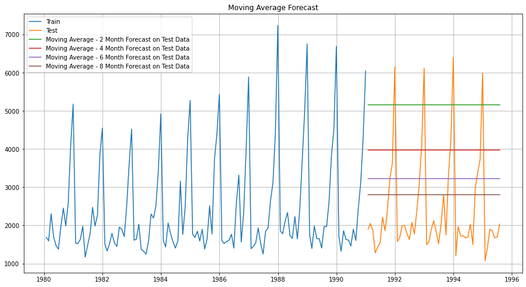

```python
# Training the model on sparkling_train dataset to predict the last value as the future value with moving average.

MovingAverage_Train = sparkling_train.copy()
MovingAverage_Test = sparkling_test.copy()

MovingAverage_2Test = (MovingAverage_Train['Sparkling'].rolling(2).mean().tail(1).repeat(len(MovingAverage_Test)))
MovingAverage_4Test = (MovingAverage_Train['Sparkling'].rolling(4).mean().tail(1).repeat(len(MovingAverage_Test)))
MovingAverage_6Test = (MovingAverage_Train['Sparkling'].rolling(6).mean().tail(1).repeat(len(MovingAverage_Test)))
MovingAverage_8Test = (MovingAverage_Train['Sparkling'].rolling(8).mean().tail(1).repeat(len(MovingAverage_Test)))

MovingAverage_2Test.index = MovingAverage_Test.index
MovingAverage_4Test.index = MovingAverage_Test.index
MovingAverage_6Test.index = MovingAverage_Test.index
MovingAverage_8Test.index = MovingAverage_Test.index

# Plot the train and test data into forecast.

plt.plot(MovingAverage_Train['Sparkling'], label='Train')
plt.plot(MovingAverage_Test['Sparkling'], label='Test')
plt.plot(MovingAverage_2Test, label='Moving Average - 2 Month Forecast on Test Data')
plt.plot(MovingAverage_4Test, label='Moving Average - 4 Month Forecast on Test Data')
plt.plot(MovingAverage_6Test, label='Moving Average - 6 Month Forecast on Test Data')
plt.plot(MovingAverage_8Test, label='Moving Average - 8 Month Forecast on Test Data')

plt.legend(loc='best')
plt.title("Moving Average Forecast")
plt.grid();
```

```python
# Calculate the error (RMSE Value) for Moving Average Model.

MovingAverage_2Month_Error = metrics.mean_squared_error(MovingAverage_Test['Sparkling'],MovingAverage_2Test,squared=False)
print("For Simple Average forecast on the Test Data,  RMSE is %3.3f" %(MovingAverage_2Month_Error))

MovingAverage_4Month_Error = metrics.mean_squared_error(MovingAverage_Test['Sparkling'],MovingAverage_4Test,squared=False)
print("For Simple Average forecast on the Test Data,  RMSE is %3.3f" %(MovingAverage_4Month_Error))

MovingAverage_6Month_Error = metrics.mean_squared_error(MovingAverage_Test['Sparkling'],MovingAverage_6Test,squared=False)
print("For Simple Average forecast on the Test Data,  RMSE is %3.3f" %(MovingAverage_6Month_Error))

MovingAverage_8Month_Error = metrics.mean_squared_error(MovingAverage_Test['Sparkling'],MovingAverage_8Test,squared=False)
print("For Simple Average forecast on the Test Data,  RMSE is %3.3f" %(MovingAverage_8Month_Error))
```

```
For Simple Average forecast on the Test Data,  RMSE is 3046.976
For Simple Average forecast on the Test Data,  RMSE is 2021.856
For Simple Average forecast on the Test Data,  RMSE is 1521.611
For Simple Average forecast on the Test Data,  RMSE is 1338.449
```

### Inference (Moving Average Model)

Simple Moving Average takes the last calculated average value of the train datset and considers it to be the flat forecast of the future. Hence no trend or seasonality is considered here defeating the purpose of forecasting. The RMSE is also high for moving average model.

### 5. Exponential Smoothing Model

##### Exponential smoothing averages or exponentially weighted moving averages consist of forecast based on previous periods data with exponentially declining influence on the older observations. Exponential smoothing methods consist of special case exponential moving with notation ETS (Error, Trend, Seasonality) where each can be none(N), additive (N), additive damped (Ad), Multiplicative (M) or multiplicative damped (Md).

#### SES - ETS(A, N, N) - Simple Exponential Smoothing

In Single ES, the forecast at time (t + 1) is given by Winters,1960

- $F_{t+1} = \alpha Y_t + (1-\alpha) F_t$

Parameter $\alpha$ is called the smoothing constant and its value lies between 0 and 1. Since the model uses only one smoothing constant, it is called Single Exponential Smoothing.

#### DES - ETS(A, A, N) - Double Exponential Smoothing

- Intercept or Level equation, $L_t$ is given by: $L_t = {\alpha}{Y_t} + (1 - \alpha)F_t$
- Trend equation is given by $T_t = {\beta}{(L_t - L_{t-1})} + (1 - \beta)T_{t-1}$

Here, $\alpha$ and $\beta$ are the smoothing constants for level and trend, respectively,

- 0 <$\alpha$ < 1 and 0 < $\beta$ < 1.

The forecast at time t + 1 is given by

- $F_{t+1} = L_t + T_t$
- $F_{t+n} = L_t + nT_t$

#### TES - ETS(A, A, A) - Triple Exponential Smoothing

In DES, we estimated the level and trend based on the optimum value of the smoothing parameters $\alpha \text{ & } \beta$. However, if there is any seasonality in the data, DES method will miss it since it neglects seasonality.

Triple Exponential Smoothing corrects for this by incorporating a seasonality component that again uses a dampening parameter $\gamma$ to incorporate seasonality variation over time.

##### a. Simple Exponential Smoothing - SES (Winter)

```
{'smoothing_level': 0.07028781452738747, 'smoothing_trend': nan, 'smoothing_seasonal': nan, 'damping_trend': nan, 'initial_level': 2107.140127789084, 'initial_trend': nan, 'initial_seasons': array([], dtype=float64), 'use_boxcox': False, 'lamda': None, 'remove_bias': False}
For SES forecast on the Test Data,  RMSE is 1338.012
```

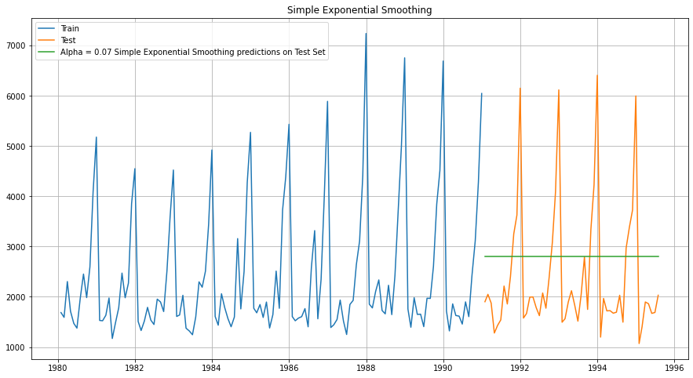

```python
# Training the model on sparkling_train dataset to predict the last value as the future value with SES Model.

SES_Train = sparkling_train.copy()
SES_Test = sparkling_test.copy()

Model_SES = SimpleExpSmoothing(SES_Train,initialization_method='estimated')
Model_SES_Autofit = Model_SES.fit(optimized=True)
SES_Predict = Model_SES_Autofit.forecast(steps=len(SES_Test))
print(Model_SES_Autofit.params)

# Plotting the Training data, Test data and the forecasted values.

plt.plot(SES_Train, label='Train')
plt.plot(SES_Test, label='Test')
plt.plot(SES_Predict, label='Alpha = 0.07 Simple Exponential Smoothing predictions on Test Set')
plt.legend(loc='best')
plt.grid()
plt.title('Simple Exponential Smoothing')

# Calculate and display the error (RMSE).

SES_Error = metrics.mean_squared_error(SES_Test.values,SES_Predict.values,squared=False)
print("For SES forecast on the Test Data,  RMSE is %3.3f" %(SES_Error))
```

##### a. Double Exponential Smoothing - DES (Holt)

```
{'smoothing_level': 0.6649999999999999, 'smoothing_trend': 0.0001, 'smoothing_seasonal': nan, 'damping_trend': nan, 'initial_level': 1502.1999999999994, 'initial_trend': 74.87272727272739, 'initial_seasons': array([], dtype=float64), 'use_boxcox': False, 'lamda': None, 'remove_bias': False}
For DES forecast on the Test Data,  RMSE is 5291.880
```

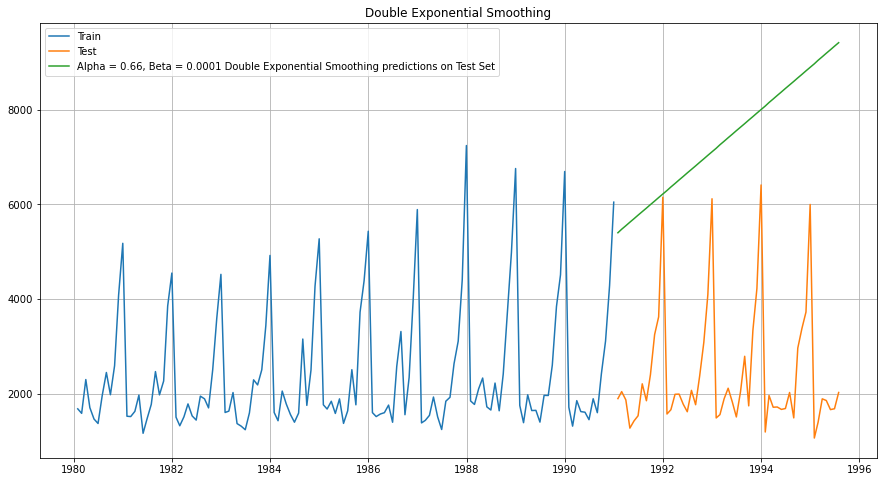

```python
# Training the model on sparkling_train dataset to predict the last value as the future value with DES Model.

DES_Train = sparkling_train.copy()
DES_Test = sparkling_test.copy()

Model_DES = Holt(DES_Train,initialization_method='estimated')
Model_DES_Autofit = Model_DES.fit()
DES_Predict = Model_DES_Autofit.forecast(steps=len(DES_Test))
print(Model_DES_Autofit.params)

# Plotting the Training data, Test data and the forecasted values.

plt.plot(DES_Train, label='Train')
plt.plot(DES_Test, label='Test')
plt.plot(DES_Predict, label='Alpha = 0.66, Beta = 0.0001 Double Exponential Smoothing predictions on Test Set')
plt.legend(loc='best')
plt.grid()
plt.title('Double Exponential Smoothing')

# Calculate and display the error (RMSE).

DES_Error = metrics.mean_squared_error(DES_Test.values,DES_Predict.values,squared=False)
print("For DES forecast on the Test Data,  RMSE is %3.3f" %(DES_Error))
```

##### a. Triple Exponential Smoothing - TES (Holt-Winter)

```
{'smoothing_level': 0.09992902361164176, 'smoothing_trend': 0.010009547876400623, 'smoothing_seasonal': 0.5100421801935793, 'damping_trend': nan, 'initial_level': 2365.591771961746, 'initial_trend': -0.09602588432632331, 'initial_seasons': array([-655.84776183, -738.31091678, -364.87202857, -484.753…
       -828.15625771, -834.85547234, -386.55684735,   93.97843967,
       -263.92294251,  264.671433  , 1584.72825037, 2622.97517826]), 'use_boxcox': False, 'lamda': None, 'remove_bias': False}
```

```
{'smoothing_level': 0.11359693142306963, 'smoothing_trend': 0.05027637823782374, 'smoothing_seasonal': 0.35951788305050486, 'damping_trend': nan, 'initial_level': 2351.2177869736306, 'initial_trend': 0.9947391482049439, 'initial_seasons': array([0.73293013, 0.70324874, 0.91349342, 0.81819362, 0.6864…
       0.67530893, 0.89665631, 1.14538134, 0.93690256, 1.23572905,
       1.94336524, 2.42258366]), 'use_boxcox': False, 'lamda': None, 'remove_bias': False}
{'smoothing_level': 0.11101677395783265, 'smoothing_trend': 0.049316382632581326, 'smoothing_seasonal': 0.3624389131056697, 'damping_trend': nan, 'initial_level': 2356.4978867323553, 'initial_trend': -9.787302694315414, 'initial_seasons': array([0.7135243 , 0.68298624, 0.90486849, 0.8056077 , 0.6558…
       0.65409923, 0.88620874, 1.13360552, 0.91938008, 1.21194659,
       1.87102251, 2.37567892]), 'use_boxcox': False, 'lamda': None, 'remove_bias': False}
```

```
{'smoothing_level': 0.11107142866032142, 'smoothing_trend': 0.012341269861019839, 'smoothing_seasonal': 0.4609259258337408, 'damping_trend': nan, 'initial_level': 2356.5416666886663, 'initial_trend': 1.003171553067385, 'initial_seasons': array([-636.18663196, -722.94704863, -398.70746525, -473.40538…
       -808.38454863, -815.31163196, -384.22829861,   72.94878474,
       -237.3949653 ,  272.33420139, 1541.2821181 , 2590.00086809]), 'use_boxcox': False, 'lamda': None, 'remove_bias': False}
For TES forecast (Additive-Additive) on the Test Data,  RMSE is 380.095
For TES forecast (Multiplicative-Multiplicative) on the Test Data,  RMSE is 386.836
For TES forecast (Additive-Multiplicative) on the Test Data,  RMSE is 402.947
For TES forecast (Multiplicative-Additive) on the Test Data,  RMSE is 354.454
```

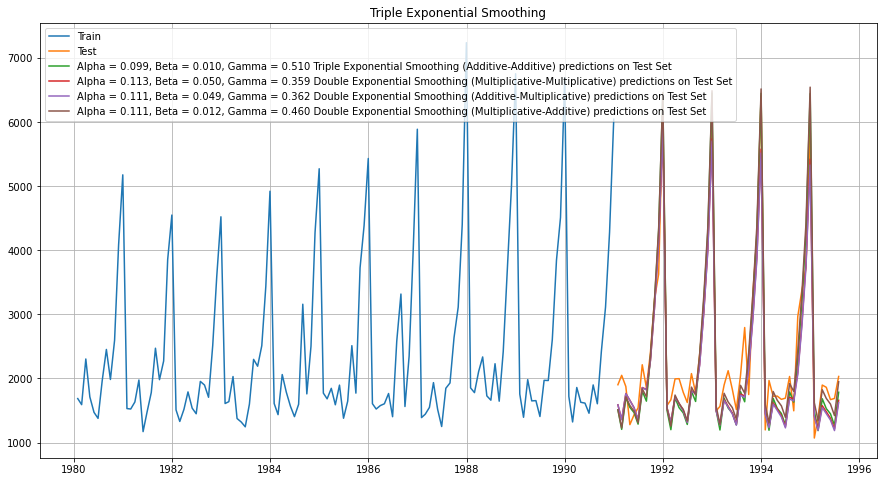

```python
# Training the model on sparkling_train dataset to predict the last value as the future value with DES Model - Additive.

TES_Train1 = sparkling_train.copy()
TES_Test1 = sparkling_test.copy()

Model_TES1 = ExponentialSmoothing(TES_Train1,trend='additive',seasonal='additive',initialization_method='estimated')
Model_TES_Autofit1 = Model_TES1.fit()
TES_Predict1 = Model_TES_Autofit1.forecast(steps=len(TES_Test1))
print(Model_TES_Autofit1.params)

# Training the model on sparkling_train dataset to predict the last value as the future value with DES Model - Multiplicative.

TES_Train2 = sparkling_train.copy()
TES_Test2 = sparkling_test.copy()

Model_TES2 = ExponentialSmoothing(TES_Train2,trend='multiplicative',seasonal='multiplicative',initialization_method='estimated')
Model_TES_Autofit2 = Model_TES2.fit()
TES_Predict2 = Model_TES_Autofit2.forecast(steps=len(TES_Test2))
print(Model_TES_Autofit2.params)

# Training the model on sparkling_train dataset to predict the last value as the future value with DES Model - Multiplicative.

TES_Train3 = sparkling_train.copy()
TES_Test3 = sparkling_test.copy()

Model_TES3 = ExponentialSmoothing(TES_Train2,trend='additive',seasonal='multiplicative',initialization_method='estimated')
Model_TES_Autofit3 = Model_TES3.fit()
TES_Predict3 = Model_TES_Autofit3.forecast(steps=len(TES_Test3))
print(Model_TES_Autofit3.params)

# Training the model on sparkling_train dataset to predict the last value as the future value with DES Model - Multiplicative.

TES_Train4 = sparkling_train.copy()
TES_Test4 = sparkling_test.copy()

Model_TES4 = ExponentialSmoothing(TES_Train2,trend='multiplicative',seasonal='additive',initialization_method='estimated')
Model_TES_Autofit4 = Model_TES4.fit()
TES_Predict4 = Model_TES_Autofit4.forecast(steps=len(TES_Test4))
print(Model_TES_Autofit4.params)

# Plotting the Training data, Test data and the forecasted values.

plt.plot(TES_Train1, label='Train')
plt.plot(TES_Test1, label='Test')
plt.plot(TES_Predict1, label='Alpha = 0.099, Beta = 0.010, Gamma = 0.510 Triple Exponential Smoothing (Additive-Additive) predictions on Test Set')
plt.plot(TES_Predict2, label='Alpha = 0.113, Beta = 0.050, Gamma = 0.359 Double Exponential Smoothing (Multiplicative-Multiplicative) predictions on Test Set')
plt.plot(TES_Predict3, label='Alpha = 0.111, Beta = 0.049, Gamma = 0.362 Double Exponential Smoothing (Additive-Multiplicative) predictions on Test Set')
plt.plot(TES_Predict4, label='Alpha = 0.111, Beta = 0.012, Gamma = 0.460 Double Exponential Smoothing (Multiplicative-Additive) predictions on Test Set')
plt.legend(loc='best')
plt.grid()
plt.title('Triple Exponential Smoothing')

# Calculate and display the error (RMSE).

TES_Error1 = metrics.mean_squared_error(TES_Test1.values,TES_Predict1.values,squared=False)
TES_Error2 = metrics.mean_squared_error(TES_Test2.values,TES_Predict2.values,squared=False)
TES_Error3 = metrics.mean_squared_error(TES_Test3.values,TES_Predict3.values,squared=False)
TES_Error4 = metrics.mean_squared_error(TES_Test4.values,TES_Predict4.values,squared=False)
print("For TES forecast (Additive-Additive) on the Test Data,  RMSE is %3.3f" %(TES_Error1))
print("For TES forecast (Multiplicative-Multiplicative) on the Test Data,  RMSE is %3.3f" %(TES_Error2))
print("For TES forecast (Additive-Multiplicative) on the Test Data,  RMSE is %3.3f" %(TES_Error3))
print("For TES forecast (Multiplicative-Additive) on the Test Data,  RMSE is %3.3f" %(TES_Error4))
```

### Q5. Build a table (create a data frame) with all the models built along the respective RMSE values on the test data.

### 1. Error Comparison Table

```python
# Creating dataframe Error_Result to house and compare all errors.

Error_Result1 = pd.DataFrame({'Test RMSE': [Naive_Model_Error]},index=['Naive Model'])
Error_Result2 = pd.DataFrame({'Test RMSE': [Linear_Regression_Error]},index=['Linear Regression Model'])
Error_Result3 = pd.DataFrame({'Test RMSE': [Simple_Average_Error]},index=['Simple Average Model'])
Error_Result4 = pd.DataFrame({'Test RMSE': [MovingAverage_2Month_Error]},index=['Moving Average - 2 Month'])
Error_Result5 = pd.DataFrame({'Test RMSE': [MovingAverage_4Month_Error]},index=['Moving Average - 4 Month'])
Error_Result6 = pd.DataFrame({'Test RMSE': [MovingAverage_6Month_Error]},index=['Moving Average - 6 Month'])
Error_Result7 = pd.DataFrame({'Test RMSE': [MovingAverage_8Month_Error]},index=['Moving Average - 8 Month'])
Error_Result8 = pd.DataFrame({'Test RMSE': [SES_Error]},index=['Simple Exponential'])
Error_Result9 = pd.DataFrame({'Test RMSE': [DES_Error]},index=['Double Exponential'])
Error_Result10 = pd.DataFrame({'Test RMSE': [TES_Error1]},index=['Triple Exponential (Additive-Additive)'])
Error_Result11 = pd.DataFrame({'Test RMSE': [TES_Error2]},index=['Triple Exponential (Multiplicative-Multiplicative)'])
Error_Result12 = pd.DataFrame({'Test RMSE': [TES_Error3]},index=['Triple Exponential (Additive-Multiplicative)'])
Error_Result13 = pd.DataFrame({'Test RMSE': [TES_Error4]},index=['Triple Exponential (Multiplicative-Additive)'])
Error_Result = pd.concat([Error_Result1, Error_Result2, Error_Result3, Error_Result4, Error_Result5, Error_Result6, Error_Result7, Error_Result8, Error_Result9, Error_Result10, Error_Result11, Error_Result12, Error_Result13])
Error_Result.sort_values('Test RMSE', ascending = False)
```

|  | Test RMSE |
| --- | --- |
| Double Exponential | 5291.879833 |
| Naive Model | 3864.279352 |
| Moving Average - 2 Month | 3046.976092 |
| Moving Average - 4 Month | 2021.855880 |
| Moving Average - 6 Month | 1521.611250 |
| Linear Regression Model | 1389.135175 |
| Moving Average - 8 Month | 1338.448533 |
| Simple Exponential | 1338.011528 |
| Simple Average Model | 1275.081804 |
| Triple Exponential (Additive-Multiplicative) | 402.946854 |
| Triple Exponential (Multiplicative-Multiplicative) | 386.836327 |
| Triple Exponential (Additive-Additive) | 380.094750 |
| Triple Exponential (Multiplicative-Additive) | 354.454157 |

### 2. Model Comparison Plot

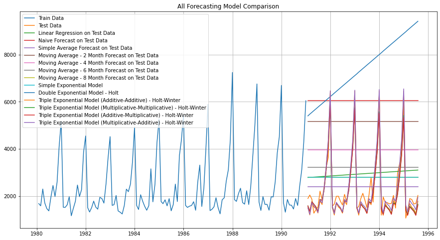

```python
plt.plot(sparkling_train, label='Train Data')
plt.plot(sparkling_test, label='Test Data')
plt.plot(LinearRegression_Test['SaleOnTime'], label='Linear Regression on Test Data')
plt.plot(NaiveModel_Test['Naive'], label='Naive Forecast on Test Data')
plt.plot(SimpleAverage_Test['AverageForecast'], label='Simple Average Forecast on Test Data')
plt.plot(MovingAverage_2Test, label='Moving Average - 2 Month Forecast on Test Data')
plt.plot(MovingAverage_4Test, label='Moving Average - 4 Month Forecast on Test Data')
plt.plot(MovingAverage_6Test, label='Moving Average - 6 Month Forecast on Test Data')
plt.plot(MovingAverage_8Test, label='Moving Average - 8 Month Forecast on Test Data')
plt.plot(SES_Predict, label='Simple Exponential Model')
plt.plot(DES_Predict, label='Double Exponential Model - Holt')
plt.plot(TES_Predict1, label='Triple Exponential Model (Additive-Additive) - Holt-Winter')
plt.plot(TES_Predict2, label='Triple Exponential Model (Multiplicative-Multiplicative) - Holt-Winter')
plt.plot(TES_Predict3, label='Triple Exponential Model (Additive-Multiplicative) - Holt-Winter')
plt.plot(TES_Predict4, label='Triple Exponential Model (Multiplicative-Additive) - Holt-Winter')

plt.legend(loc='best')
plt.grid()
plt.title('All Forecasting Model Comparison');
```

```python
# Use the same TES Model and predict 12 additional months.

TES_Predict = Model_TES_Autofit4.forecast(steps=len(TES_Test4)+12)
print('Forecasted Sales for 12 additional Months (TES - Multiplicative Model)')
print(TES_Predict.tail(12))
```

```
Forecasted Sales for 12 additional Months (TES - Multiplicative Model)
1995-08-31    1824.729900
1995-09-30    2463.591681
1995-10-31    3375.480264
1995-11-30    4452.082706
1995-12-31    6575.981524
1996-01-31    1650.010429
1996-02-29    1366.056263
1996-03-31    1852.364194
1996-04-30    1716.871693
1996-05-31    1628.997140
1996-06-30    1448.617905
1996-07-31    1977.008964
Freq: M, dtype: float64
```

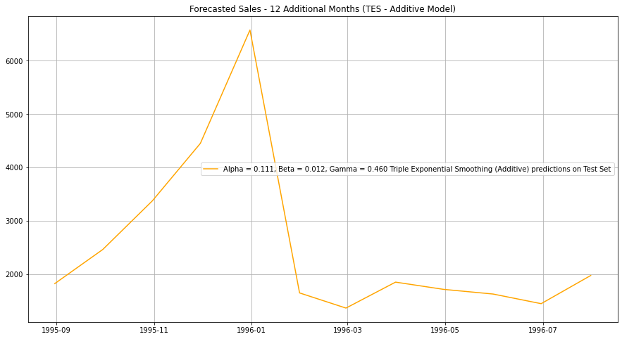

```python
# Plot the Forecasted Sales - 12 Months.

plt.plot(TES_Predict.tail(12), label='Alpha = 0.111, Beta = 0.012, Gamma = 0.460 Triple Exponential Smoothing (Additive) predictions on Test Set', color='orange')
plt.legend(loc='best')
plt.grid()
plt.title('Forecasted Sales - 12 Additional Months (TES - Additive Model)')
```

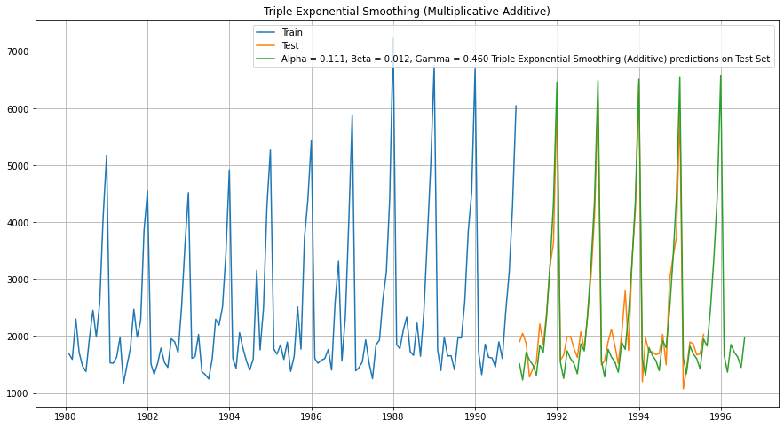

```python
# Plot the Train, Test, Forecasted Sales (12 Motnhs).

plt.plot(TES_Train1, label='Train')
plt.plot(TES_Test1, label='Test')
plt.plot(TES_Predict, label='Alpha = 0.111, Beta = 0.012, Gamma = 0.460 Triple Exponential Smoothing (Additive) predictions on Test Set')
plt.legend(loc='best')
plt.grid()
plt.title('Triple Exponential Smoothing (Multiplicative-Additive)')
```

### Q7. Comment on the model thus built and report your findings and suggest the measures that the company should be taking for future sales.

#### Model Forecasting Summary

| Model Type | RMSE Value | Prediction Outcome |
| --- | --- | --- |
| Naive Model | 3864 | Prediction values for all test datapoints is same as last value of training dataset. |
| Linear Regression Model | 1389 | Prediction based on the assumption that a linear relationship exists between time and sales. |
| Simple Average Model | 1275 | Prediction values for all test datapoints is equal to the average value of training dataset. |
| Moving Average Model (2, 4, 6, 8 Month) | 3046, 2021, 1521, 1338 | Prediction values for all test datapoints is equal to the average value of the training dataset (2, 4 6, 8 Month). |
| Simple Exponential Model | 1338 | Predicted values is based on an estimated level based on optimum value of the smoothing parameter 𝛼 (No Trend / Seasonality). |
| Double Exponential Model | 5292 | Predicted values is based on estimated level based on the optimum value of the smoothing parameter 𝛼 and also a trend component based on the value of Beta (No Seasonality). |
| Triple Exponential Model (Multiplicative/Additive) | 402, 386, 380, 354 | Predicted values is estimated level (baed on alpha), trend (based on beta), seasonality (based on gamma). |